# Homework 07 - Likelihood Homework

Andrew Judell-Halfpenny

```r
library(ggplot2);library(tidyverse)
library(stats4);library(MASS)
library(profileModel);library(modelr)
library(viridis); library(bbmle)
puffer <- read_csv("http://www.zoology.ubc.ca/~whitlock/ABD/teaching/datasets/16/16q11PufferfishMimicry%20Caley%20&%20Schluter%202003.csv")
seals<-read_csv("http://www.zoology.ubc.ca/~whitlock/ABD/teaching/datasets/17/17e8ShrinkingSeals%20Trites%201996.csv")
parallel::detectCores()
```

```
## [1] 8
```

```r
options(mc.cores = parallel::detectCores())
```

# 1. Grid Sampling!

> Based on Friday’s lab, load up the pufferfish data and use grid sampling to find the MLE of the slope, intercept and residual SD of this model. Feel free to eyeball results from an `lm()` fit to get reasonable values. Try not to do this for a grid of more than ~100K points (more if you want!). It’s ok to be coarse. Compare to lm.

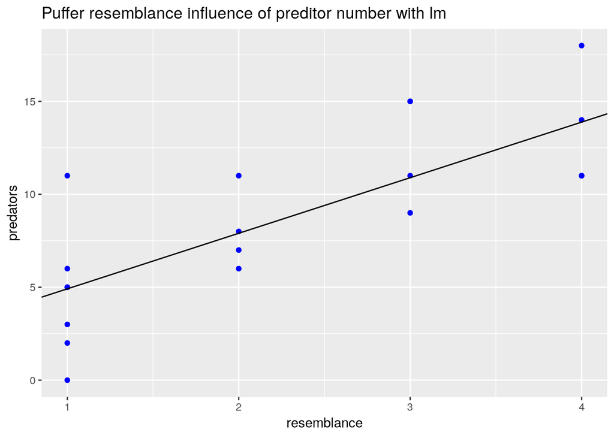

```r
puffer.lm <- lm(predators ~ resemblance, data = puffer)

ggplot(data = puffer, aes(y=predators, x=resemblance))+
   geom_point(col="blue")+
   ggtitle("Puffer resemblance influence of preditor number with lm")+
   geom_abline(data=puffer.lm,aes(intercept=puffer.lm$coefficients[1],
                                  slope=puffer.lm$coefficients[2]))
```

```r
sd(puffer.lm$residuals)
```

```
## [1] 2.971769
```

```r
puffer.lm.info<-summary(puffer.lm)
puffer.lm.info
```

```
##
## Call:
## lm(formula = predators ~ resemblance, data = puffer)
##
## Residuals:
##     Min      1Q  Median      3Q     Max
## -4.9142 -2.1563  0.0858  1.5884  6.0858
##
## Coefficients:
##             Estimate Std. Error t value Pr(>|t|)
## (Intercept)   1.9247     1.5064   1.278    0.218
## resemblance   2.9895     0.5714   5.232 5.64e-05 ***
## ---
## Signif. codes:  0 '***' 0.001 '**' 0.01 '*' 0.05 '.' 0.1 ' ' 1
##
## Residual standard error: 3.053 on 18 degrees of freedom
## Multiple R-squared:  0.6033, Adjusted R-squared:  0.5812
## F-statistic: 27.37 on 1 and 18 DF,  p-value: 5.638e-05
```

```r
likelihood <- function(m, b, residual.sd){
  predator.fitted <- b + m * puffer$resemblance
  sum(dnorm(puffer$predators, predator.fitted, residual.sd, log=TRUE))}

samp <- crossing(b = seq(0.4, 3.5, .05),
                      m = seq(2.4,3.5,.05),
                      residual.sd = seq(2.75, 3.5, .05)) %>%
  rowwise() %>%
  mutate(logLik = likelihood(m, b, residual.sd)) %>%
  ungroup()

#the ML estimates are
samp %>% filter(logLik == max(logLik)) -> samp.mle
samp.mle
```

```
## # A tibble: 1 x 4
##       b     m residual.sd logLik
##   <dbl> <dbl>       <dbl>  <dbl>
## 1   1.9     3         2.9  -49.6
```

# 2. Surfaces!

> Filter the dataset to the MLE of the SD. Plot the surface for the slope and intercept in whatever way you find most compelling. You might want to play around with zooming in to different regions, etc. Have fun!

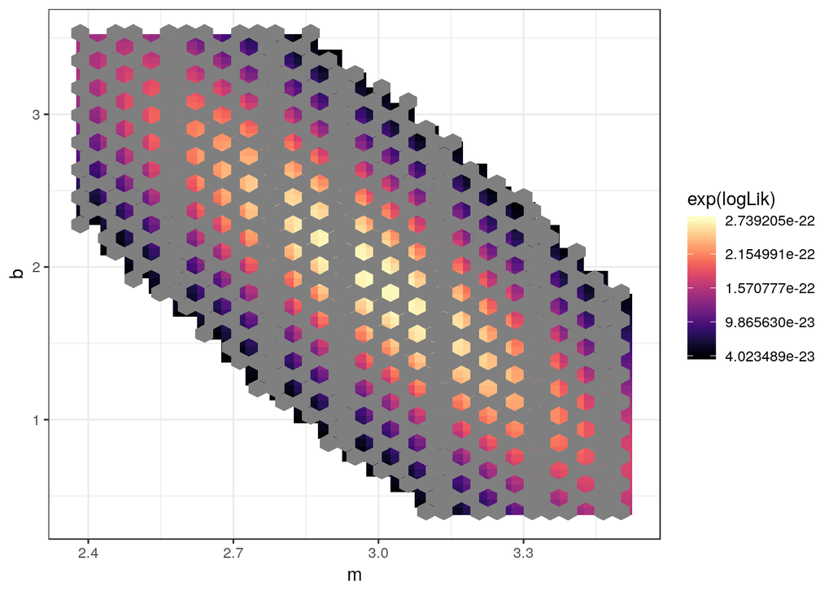

```r
ggplot(samp %>% filter(residual.sd == 2.9)
       %>%   filter(logLik >  max(logLik) - 1.92),
       aes(x = m, y = b, fill = exp(logLik)))+
       geom_raster()+
   geom_hex()+
   scale_fill_viridis(option="magma") + theme_bw()
```

# 3. GLM!

> Now, compare those results to results from glm. Show the profiles and confidence intervals from `glm()` for the slope and intercept.

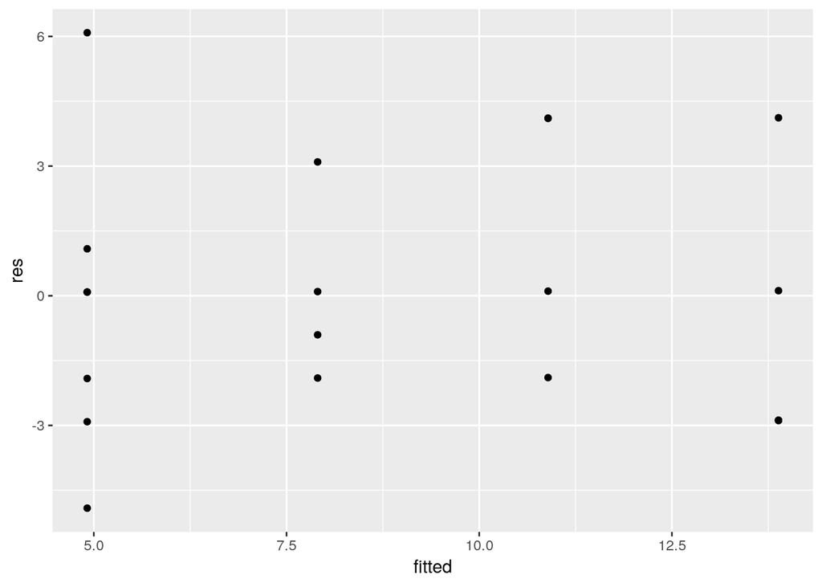

```r
puffer.glm <- glm(predators ~ resemblance, data = puffer,
                 family = gaussian(link = "identity"))

fitted <- predict(puffer.glm)
res <- residuals(puffer.glm)
qplot(fitted, res)
```

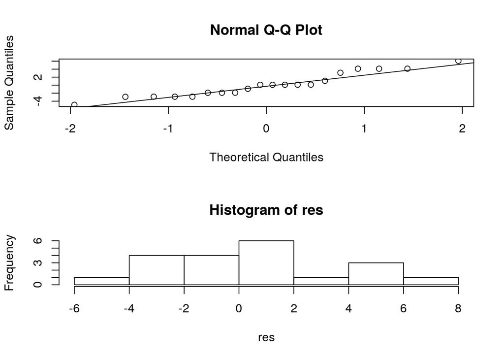

```r
par(mfrow=c(2,1))
qqnorm(res)
qqline(res)
hist(res)
```

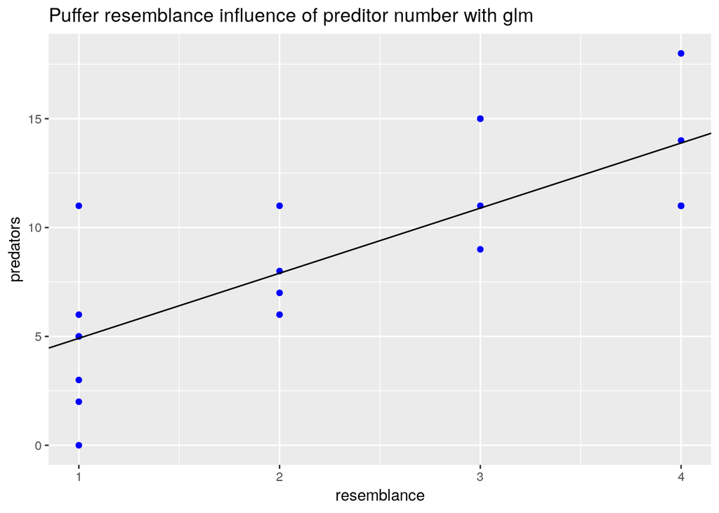

```r
par(mfrow=c(1,1))

ggplot(data = puffer, aes(y=predators, x=resemblance))+
   geom_point(col="blue")+
   ggtitle("Puffer resemblance influence of preditor number with glm")+
   geom_abline(data=puffer.glm,aes(intercept=puffer.glm$coefficients[1],
                                  slope=puffer.glm$coefficients[2]))
```

```r
puffer.profile <- profileModel(puffer.glm,
                     objective = "ordinaryDeviance",
                     quantile = qchisq(0.95, 1))
```

```
## Preliminary iteration .. Done
##
## Profiling for parameter (Intercept) ... Done
## Profiling for parameter resemblance ... Done
```

```r
puffer.profile
```

```
##
## Call:  profileModel(fitted = puffer.glm, quantile = qchisq(0.95, 1),      objective = "ordinaryDeviance")
##
## Profiled parameters:
## [1]  (Intercept)  resemblance
##
## Asymptotes:
## profileModel has not detected any profiles with asymptotes.
##
## Quantile was set to: 3.841459
## Grid size: 20
##
## Agreement of the objective with fitting method glm : TRUE
## Values of the objective less than 1e-08 were considered 0
## The profile traces are included in the object.
```

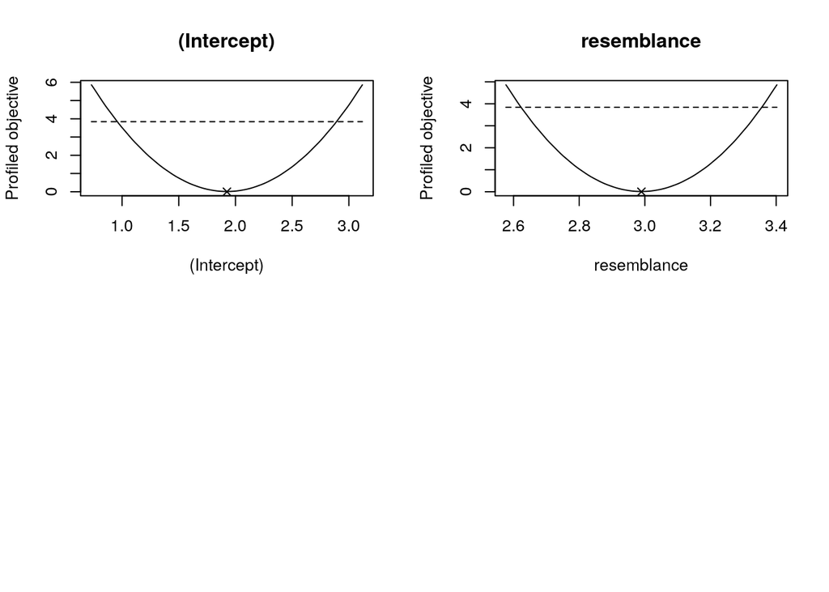

```r
plot(puffer.profile)
```

```r
print(paste0("The confidence interval for the Intercept is ",
             confint(puffer.glm)[1,1], " to ", confint(puffer.glm)[1,2]))
```

```
## [1] "The confidence interval for the Intercept is -1.0278280782092 to 4.87721511848941"
```

```r
print(paste0("The confidence interval for the slope is ",
             confint(puffer.glm)[2,1], " to ", confint(puffer.glm)[2,2]))
```

```
## [1] "The confidence interval for the slope is 1.86953684064514 to 4.1094473975335"
```

# 4. Get Outside of GLM!

```r
minimum.likelihood<-function(m, b, residual.sd) -1*likelihood(m,b, residual.sd)
puffer.lm
```

```
##
## Call:
## lm(formula = predators ~ resemblance, data = puffer)
##
## Coefficients:
## (Intercept)  resemblance
##       1.925        2.989
```

```r
puffer.mle2 <- mle2(minimum.likelihood, start = list(m = 1.9, b = -1, residual.sd = 3))

summary(puffer.mle2)
```

```
## Maximum likelihood estimation
##
## Call:
## mle2(minuslogl = minimum.likelihood, start = list(m = 1.9, b = -1,
##     residual.sd = 3))
##
## Coefficients:
##             Estimate Std. Error z value     Pr(z)
## m            2.98971    0.54210  5.5151 3.486e-08 ***
## b            1.92401    1.42913  1.3463    0.1782
## residual.sd  2.89655    0.45799  6.3245 2.541e-10 ***
## ---
## Signif. codes:  0 '***' 0.001 '**' 0.01 '*' 0.05 '.' 0.1 ' ' 1
##
## -2 log L: 99.29798
```

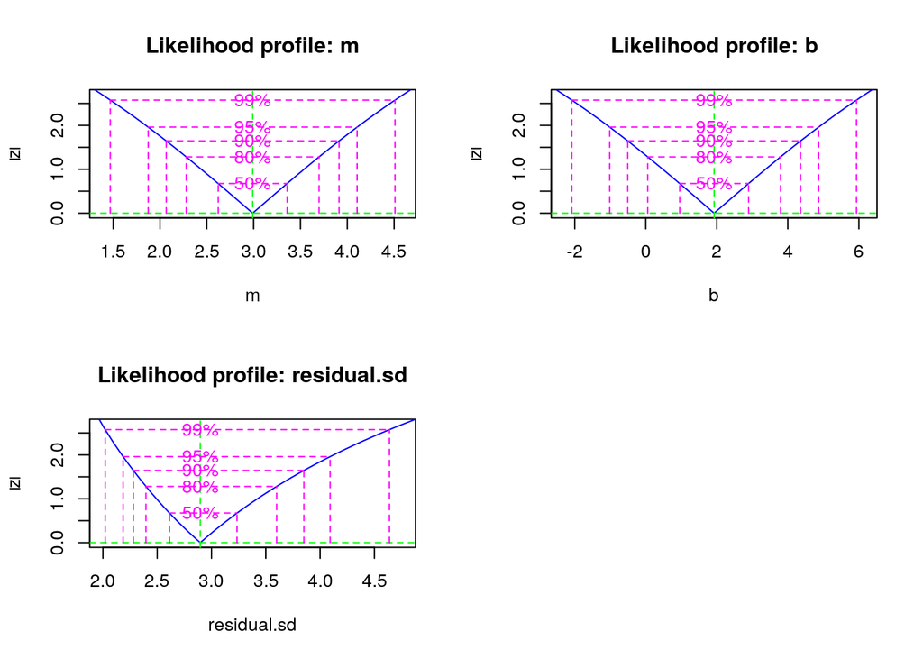

```r
plot(profile(puffer.mle2))
```

# 5. Start values!

> What happens if you start with start values *very* far away from the initial values. Failing here is fine. But what do you think is happening, and what does this say about the value of start values?

```r
mle.far<-mle2(minimum.likelihood, start = list(m = 300, b = -300, residual.sd = 0.1))
mle.far
```

```
##
## Call:
## mle2(minuslogl = minimum.likelihood, start = list(m = 300, b = -300,
##     residual.sd = 0.1))
##
## Coefficients:
##           m           b residual.sd
##    2.989495    1.924688    2.896518
##
## Log-likelihood: -49.65
```

# 6. Algorithms!

> By default, `mle2` uses the Nelder-Mead algorithm via the `optim` function. What happens if you add an `method` argument to “SANN” or “L-BFGS-B” (and for the later, which is bounded sampling, give it a `lower` argument for your residual value, so it’s always positive). See `?optim` for some more guidance. Do these both converge to the same value? Based on their profiles, do you trust them? (Note, Simulated annealing takes a looooong time. Go have a cuppa while the profile for that one runs).

```r
puffer.sann <- mle2(minimum.likelihood,
                    start = list(m = 1.9, b = 1,
                                 residual.sd = 2),
                    method = "SANN")

summary(puffer.sann)
```

```
## Maximum likelihood estimation
##
## Call:
## mle2(minuslogl = minimum.likelihood, start = list(m = 1.9, b = 1,
##     residual.sd = 2), method = "SANN")
##
## Coefficients:
##             Estimate Std. Error z value     Pr(z)
## m            2.92802    0.54761  5.3469 8.947e-08 ***
## b            2.04616    1.44324  1.4178    0.1563
## residual.sd  2.92410    0.46907  6.2338 4.554e-10 ***
## ---
## Signif. codes:  0 '***' 0.001 '**' 0.01 '*' 0.05 '.' 0.1 ' ' 1
##
## -2 log L: 99.3154
```

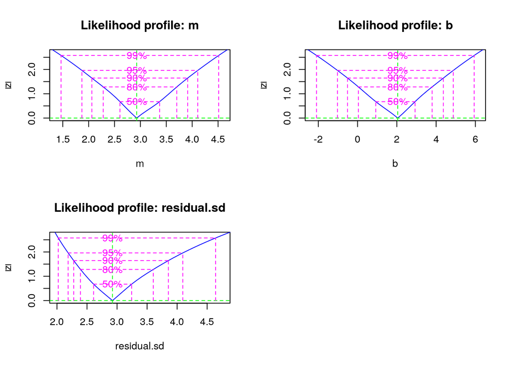

```r
plot(profile(puffer.sann))
```

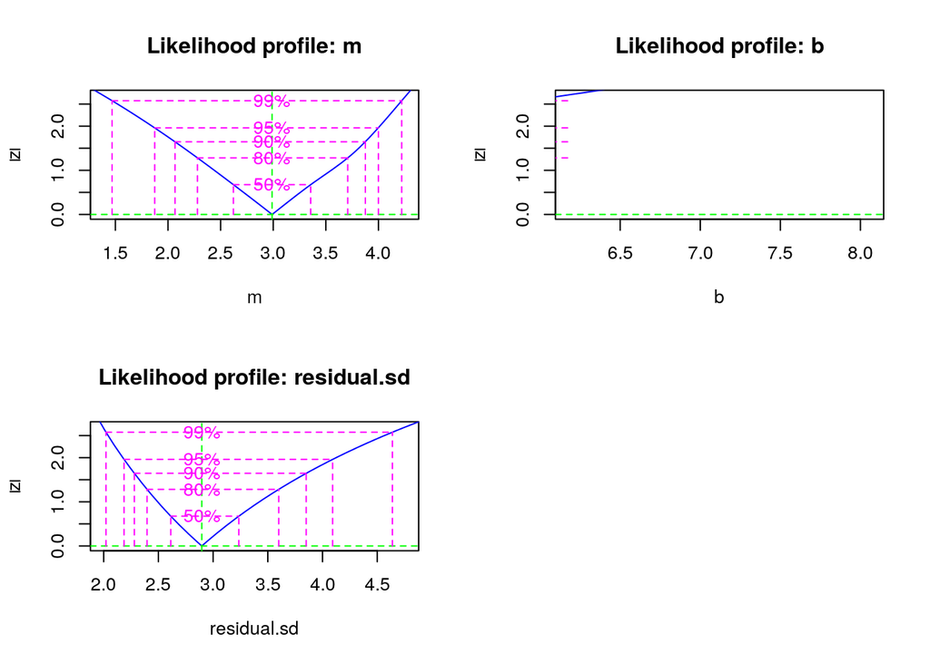

```r
puffer.bfgs <- mle2(minimum.likelihood,
                    start = list(m = 1.9, b = 1,
                                 residual.sd = 2),
                    method = "L-BFGS-B",
                    lower=c(residual.sd = 0.1))

plot(profile(puffer.bfgs))
```

```r
summary(puffer.bfgs)
```

```
## Maximum likelihood estimation
##
## Call:
## mle2(minuslogl = minimum.likelihood, start = list(m = 1.9, b = 1,
##     residual.sd = 2), method = "L-BFGS-B", lower = c(residual.sd = 0.1))
##
## Coefficients:
##             Estimate Std. Error z value     Pr(z)
## m            2.98949    0.54209  5.5147 3.493e-08 ***
## b            1.92469    1.42911  1.3468    0.1781
## residual.sd  2.89652    0.45798  6.3245 2.540e-10 ***
## ---
## Signif. codes:  0 '***' 0.001 '**' 0.01 '*' 0.05 '.' 0.1 ' ' 1
##
## -2 log L: 99.29798
```

## 6. Answer:

> Both methods seem to produce similar estimates for slobe, intercept and residual st deviation. Howeber the standard error of the intercept is the same order of magnitude as the value of the intercept estimate. The L-BFGS-B method also produced a Likelihood profile plot for the intercept that is completely uninformative despite changing the lower bound several times.